# R Notebook

### Backtransforming model coefficients

Finally, you’ll note that the dependent or response variable in our model was log(startDayOfYear) rather than just startDayOfYear. That means that we need consider that transformation when interpreting the coefficient estimates. Really what we are saying is that (look at this in the Preview view):

$ln(Y) = \beta_0 + \beta_1*year + \beta_2*tmean + \beta_3*ppt$

which is the same as

$Y = e^{\beta_0 + \beta_1*year + \beta2*tmean + \beta3*ppt}$

which is the same as

$Y = e^{\beta_0}*e^{\beta_1*year}*e^{\beta2*tmean}*e^{\beta3*ppt}$

### Plotting/interpreting model estimates

Let’s plot that:

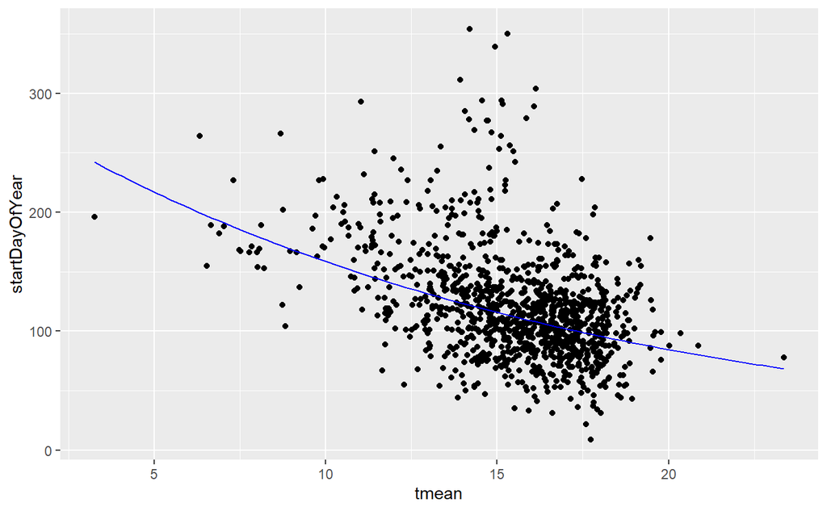

```r
mean_year <- mean(CA_poppy_separate$year)
mean_ppt <- mean(CA_poppy_separate$ppt)

CA_poppy_separate %>%
  ggplot(aes(x = tmean, y = startDayOfYear)) +
  geom_point() +
  geom_function(fun = function(x) exp(6.401e+00)*exp(-3.703e-04*mean_year)*exp(-6.277e-02*x)*exp(5.793e-05*mean_ppt),
                color = "blue")
```

The plot is a demonstration that the relationship between the two variables can be plotted. There’s a lot of variation around the line, but the points kind of follow it.